# Topic 1; Clustering: K-means, Hierarchical Clustering

# K-means

The K-means is an unsupervised partitioning clustering method. No response variable. It is partitioning because it creates independent groups dissimilar between them, but similar within.

Assume we have data $D = (x_1,\ldots,x_n)$ where $x_i\in\mathbb{R}^p$. The idea of K-means is to assign them into K different groups where the elements inside one group is as similar as possible.

Denote $C_1,\ldots,C_K$ the $K$ different groups. The K-means method solves

$$\begin{align*}
min_{C_1,\ldots,C_K}\left(\sum_{k=1}^KW(C_k)\right)
\end{align*}$$

Where $W(C_k)$ is the withing cluster variation, i.e. dissimilarity within the k’th cluster. The most used dissimilarity measure is the squared Euclidian distance, i.e.

$$\begin{align*}
W(C_k) := \frac{1}{|C_k|}\sum_{i,i'\in C_k}\sum_{j=1}^p(x_{i,j}-x_{i',j})^2
\end{align*}$$

The solution can be too hard to obtain due to the vast amount of combinations. As a result, K-means uses a greedy algorithm that gives local solutions. A greedy algorithm is an algorithm that always chooses the next value that offers the most obvious and immediate benefit. Thus local solutions, and not necessarily global solutions.

Returning to the problem, by substituting the dissimilarity measure chosen, we get that K-means looks to solve

$$\begin{align*}
min_{C_1,\ldots,C_K}\left(\sum_{k=1}^K\frac{1}{|C_k|}\sum_{i,i'\in C_k}\sum_{j=1}^p(x_{i,j}-x_{i',j})^2\right).
\end{align*}$$

Next, let $\bar{x}_{k,j} = \frac{1}{|C_k|}\sum_{i\in C_k}x_{i,j}$. Then we have that

$$\begin{align*}
\frac{1}{|C_k|}\sum_{i,i'\in C_k}\sum_{j=1}^p(x_{i,j}-x_{i',j})^2 &=
\frac{1}{|C_k|}\sum_{i,i'\in C_k}\sum_{j=1}^p(x_{i,j}-\bar{x}_{k,j} + \bar{x}_{k,j} -x_{i',j})^2\\
& = \frac{1}{|C_k|}\sum_{i,i'\in C_k}\sum_{j=1}^p \left((x_{i,j}-\bar{x}_{k,j})^2
+(\bar{x}_{k,j} -x_{i',j})^2 + 2(x_{i,j}-\bar{x}_{k,j})(\bar{x}_{k,j} -x_{i',j})\right)
\end{align*}$$

Next, notice that $\sum_{i,i'\in C_k}=\sum_{i\in C_k}\sum_{i'\in C_k}$ (it is a double sum). Additionally, there are $|C_k|$ elements in each cluster. Using this, swapping the sums and the previous equations yields that

$$\begin{align*}
\frac{1}{|C_k|}\sum_{i,i'\in C_k}\sum_{j=1}^p(x_{i,j}-x_{i',j})^2 &= \frac{1}{|C_k|}
\left\{\sum_{j=1}^p|C_k|\sum_{i}(x_{i,j}-\bar{x}_{k,j})^2+\sum_{j=1}^p|C_k|\sum_{i'}
(\bar{x}_{k,j}-x_{i',j})^2 \right\}\\
&+ \frac{2}{|C_k|}\sum_{j=1}^p\sum_{i}\sum_{i'}(x_{i,j}\bar{x}_{k,j}-x_{i,j}x_{i',j}
-\bar{x}_{k,j}^2 + \bar{x}_{k,j}x_{i',j})\\
&= 2\sum_{j=1}^p\sum_i(x_{i,j}-\bar{x}_{k,j})^2\\
&+ \frac{2}{|C_k|}\sum_{j=1}^p\left\{\bar{x}_{k,j}|C_k|\sum_ix_{i,j}-\sum_i\sum_{i'}
x_{i,j}x_{i',j}-|C_k|^2\bar{x}_{k,j}^2+\bar{x}_{k,j}|C_k|\sum_{i'}x_{i',j}\right\}\\
&=2\sum_{i}\sum_{j=1}^p(x_{i,j}-\bar{x}_{k,j})^2\\
&+ \frac{2}{|C_k|}\sum_{j=1}^p\left\{\sum_i x_{i,j} \sum_{i'} x_{i',j} -
\sum_{i} x_{i,j}\sum_{i'} x_{i',j} - \sum_{i} x_{i,j}\sum_{i'} x_{i',j} +
\sum_{i} x_{i,j}\sum_{i'} x_{i',j}\right\}\\
&=2\sum_{i}\sum_{j=1}^p(x_{i,j}-\bar{x}_{k,j})^2
\end{align*}$$

For the second to last equality, we used the definition of $\bar{x}_{k,j}$ and the fact that $i$ and $i'$ are interchangeable. Substituting this into the original problem yields that K-means looks to solve

$$\begin{align*}
min_{C_1,\ldots,C_K}\left(2\sum_{k=1}^K\sum_{i\in C_k}\sum_{j=1}^p(x_{i,j}-\bar{x}_{k,j})^2\right).
\end{align*}$$

Next, note that

$$\begin{align*}
\bar{x}_{k,j} = min_{\mu_k}\left\{\sum_{i\in C_k}\sum_{j=1}^p(x_{i,j}-\mu_k)^2\right\}.
\end{align*}$$

That is, if we want to explain the response with a constant, the solution to this problem is the mean, $\bar{x}_{k,j}$. Hence we can instead consider the problem

$$\begin{align*}
min_\underset{\mu_1,\ldots,\mu_K}{C_1,\ldots,C_K}\left(\sum_{k=1}^K\sum_{i\in C_k}\sum_{j=1}^p(x_{i,j}-\mu_k)^2\right).
\end{align*}$$

Thus K-means tries to iteratively solve for $\{C_1,\ldots,C_K\}$ and $\{\mu_1,\ldots,\mu_K\}$, that is, the clusters and the cluster means. It first starts by finding the clusters, then calculating means, finding new clusters, etc until convergence. This means that the K-means is a greedy algorithm. The algorithm itself is given by the following

1. Choose the number of cluster K.
2. Randomly assign each element to one of the K different clusters, which is the initial clusters.
3. For each cluster, compute the centroid, $c_k$, that is, the mean of the observations in the cluster $C_k$,

$$\begin{align*}
c_k = |C_k|^{-1}\sum_{i\in C_k}x_i
\end{align*}$$

4. Compute the distances from each point to the centroids and assign each observation to the closets centroid.
5. Repeat 3-4 until convergence.

Because the algorithm is greedy, we are not assured a global minimum. To circumvent this, one runs the algorithm multiple times from different initial values and then selects the combinations of clusters that minimizes the objective function.

### Choosing K

If we have no prior knowledge about how to choose $K$, we need to decide. To do this, first define

$$\begin{align*}
SS_{TOT} = \sum_{i=1}^n(x_i-\bar{x})^2, \quad \bar{x}=n^{-1}\sum_{i=1}^n x_i.
\end{align*}$$

This is total sum of squares. Similarly, the withing cluster sum of squares is

$$\begin{align*}
SS_{W_k} = \sum_{i\in C_k}(x_i-\bar{x}_k)^2, \quad \bar{x}_k = |C_k|^{-1}\sum_{i\in C_k}x_i
\end{align*}$$

Hence the total sum of squares withing cluster is given by $SS_W = \sum_{k=1}^K SS_{W_k}$. We can then calculate the ratio of $SS_W$ and $SS_{TOT}$, that is, calculate the total variation inside the clusters to the case if we had made no clusters at all. This is defined as PVE, the percentage of variance explained;

$$\begin{align*}
PVE=\frac{SS_W}{SS_{TOT}}.
\end{align*}$$

The general idea is then to plot the value of the PVE against the number of clusters made, and use the elbow method/scree plot to decide on the number of clusters. It is also important to standardize the data before hand, because the K-means is sensitive to units of measurements and outliers.

# Hierarchical clustering

The way Hierarchical clustering works is by iteratively diving the data into nested sub-clusters. Hence this algorith does not suffer from deciding a number of clusters. There are two types of hierarchical clustering;

#### Agglomerative

Starts with each observation defining its own cluster and joining the most similar ones.

#### Divise

Starts with one cluster and splits recursively the least homogeneous cluster into sub-clusters

The algorithm for the agglomerative hierarchical clustering is given by

1. Start with the $n$ observations, define a dissimilarity measure, e.g. eucedian distance, and treat each observation as its own cluster
2. Examine all pairwise inter-cluster dissimilarities among the $j$ clusters and identify the pair of clusters that are most similar. Fuse these clusters. The dissimilarity between these two clusters indicates the height in the dendogram at which the fusion should be placed.
3. Compute the new pairwise inter-cluster dissimilarities among the $j-1$ remaning clusters.
4. Repeat 2-3 for $j=n,n-1,\ldots,2$.

### Linkage

It is important to specify how to measure dissimilarity between clusters when there are multiple points present in each cluster. There are multiple ways to do this. This is called linkage.

##### Complete

The largest pairwise dissimilarity between clusters’ members

##### Single

The smallest pairwise dissimilarity between clusters’ members

##### Average

The mean of all the pairwise dissimilarities between clusters’ members

##### Centroid

Dissimilarity between clusters’ centroids. Inversion can occur if this is used, because the e.g. the distance between two points inside a cluster is larger than the distance from that cluster to a new observation, because we introduce a new point to measure the distance, i.e. the centroid.

# Practical Application of these on the Iris data set

Assume that we do not know that there are 3 species of flowers. Lets make use of the elbow method to decide of the amount of clusters to use in K-means.

```r
suppressMessages(library(tidyverse))
library(ggplot2)
data("iris")

Dat <- iris %>% select(-Species)
str(Dat)
```

```
## 'data.frame':    150 obs. of  4 variables:
##  $ Sepal.Length: num  5.1 4.9 4.7 4.6 5 5.4 4.6 5 4.4 4.9 ...
##  $ Sepal.Width : num  3.5 3 3.2 3.1 3.6 3.9 3.4 3.4 2.9 3.1 ...
##  $ Petal.Length: num  1.4 1.4 1.3 1.5 1.4 1.7 1.4 1.5 1.4 1.5 ...
##  $ Petal.Width : num  0.2 0.2 0.2 0.2 0.2 0.4 0.3 0.2 0.2 0.1 ...
```

```r
head(Dat)
```

```
##   Sepal.Length Sepal.Width Petal.Length Petal.Width
## 1          5.1         3.5          1.4         0.2
## 2          4.9         3.0          1.4         0.2
## 3          4.7         3.2          1.3         0.2
## 4          4.6         3.1          1.5         0.2
## 5          5.0         3.6          1.4         0.2
## 6          5.4         3.9          1.7         0.4
```

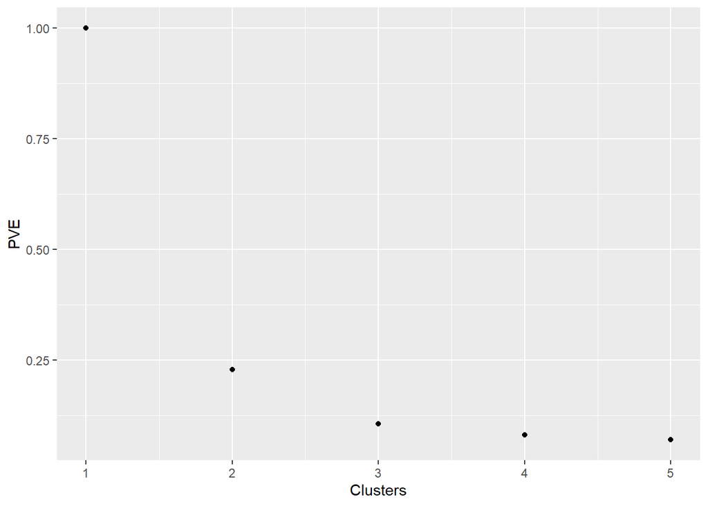

```r
Dat_Standardized <- sapply(Dat, FUN = function(x){
  x/max(x)
})

Dat_Compare_Standardized <- Dat_Standardized %>% as.data.frame %>%
  mutate(Species = as.numeric(iris$Species))


Albuen <- c()
for (i in 1:5) {
  tmp <- kmeans(Dat_Standardized, i, nstart = 50)
  Albuen[i] <- tmp$tot.withinss/tmp$totss
}
Albue_Plot <- tibble(PVE = Albuen, Clusters = seq_along(PVE))

ggplot(data = Albue_Plot, mapping = aes(x = Clusters, y = PVE)) +
  geom_point()
```

From the elbow method, we would most likely be satisfied with 2 clusters, when in reality, 3 clusters are present in the data. It is arguable that 3 clusters should be chosen according to the plot, but that is up to the individual.

The true data looks like this:

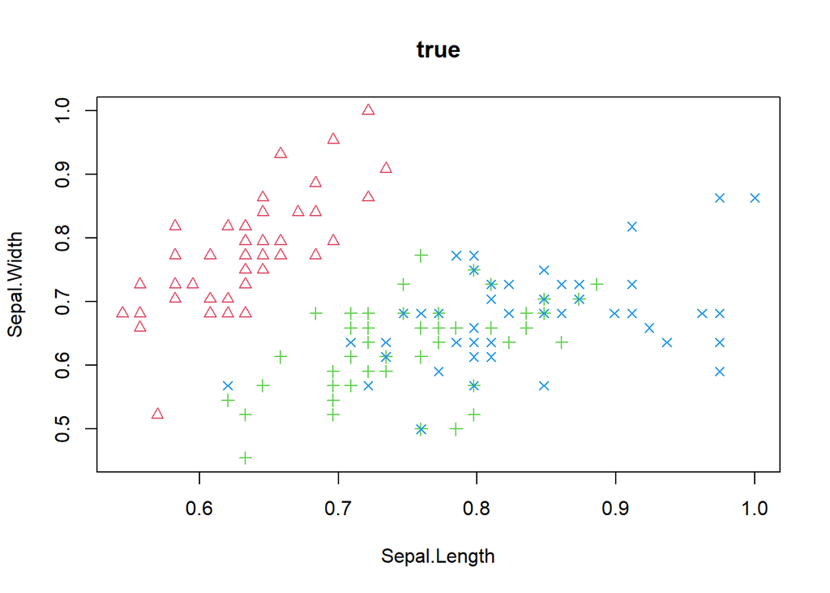

```r
plot(Dat_Standardized[,1:2], pch = Dat_Compare_Standardized$Species + 1, col = Dat_Compare_Standardized$Species + 1, main = "true")
```

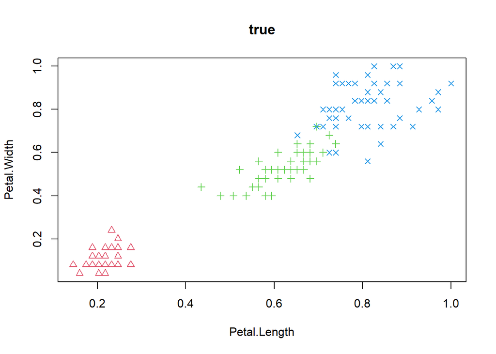

```r
plot(Dat_Standardized[,3:4], pch = Dat_Compare_Standardized$Species + 1, col = Dat_Compare_Standardized$Species + 1, main = "true")
```

We can try kmeans on this, like so

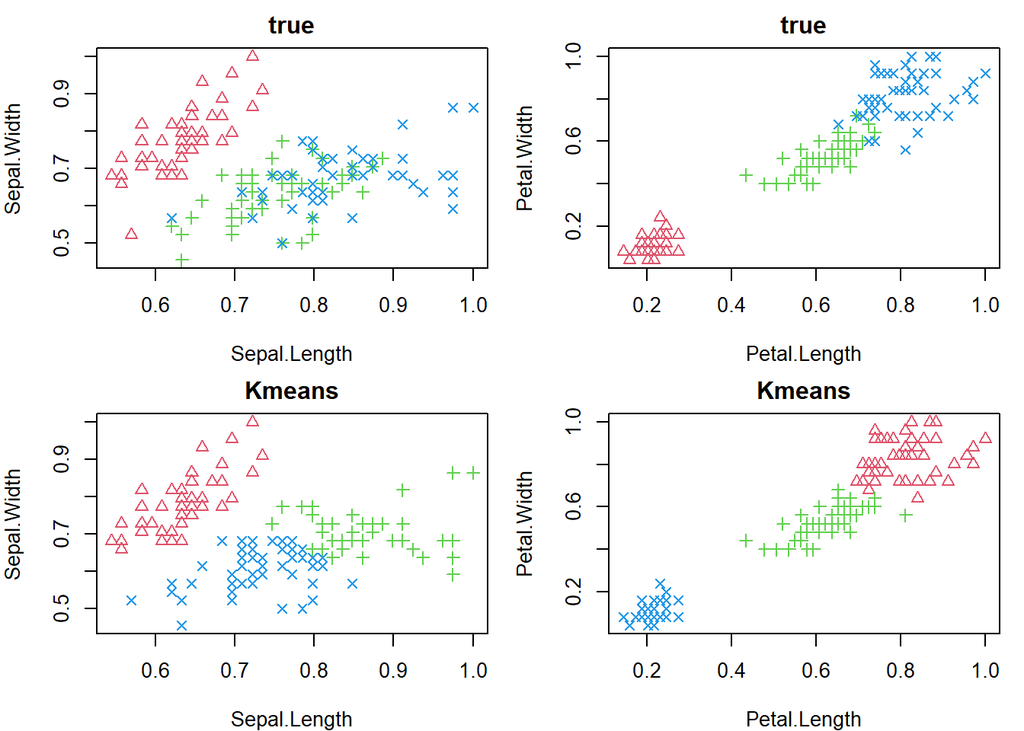

```r
par(mfrow=c(2,2))
par(mar=c(4,4,2,1))
kmeans_12 <- kmeans(Dat_Standardized[,1:2], centers = 3,nstart = 50)
kmeans_34 <- kmeans(Dat_Standardized[,3:4], centers = 3,nstart = 50)

plot(Dat_Standardized[,1:2], pch = Dat_Compare_Standardized$Species + 1, col = Dat_Compare_Standardized$Species + 1, main = "true")
plot(Dat_Standardized[,3:4], pch = Dat_Compare_Standardized$Species + 1, col = Dat_Compare_Standardized$Species + 1, main = "true")
plot(Dat_Standardized[,1:2], pch = kmeans_12$cluster + 1, col = kmeans_12$cluster + 1, main = "Kmeans")
plot(Dat_Standardized[,3:4], pch = kmeans_34$cluster + 1, col = kmeans_34$cluster + 1, main = "Kmeans")
```

Lets now try to use Hierarchical Clustering

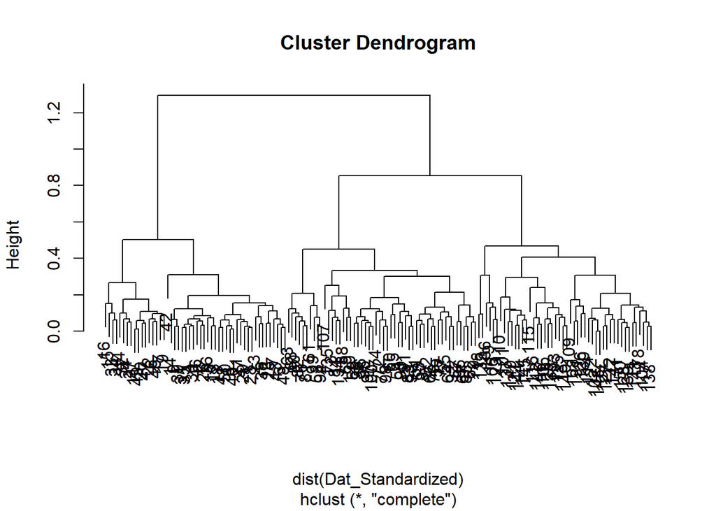

```r
par(mfrow=c(1,1))
Complete_hclust <- hclust(d = dist(Dat_Standardized), method = "complete")

#Dendogram for complete
plot(Complete_hclust)
```

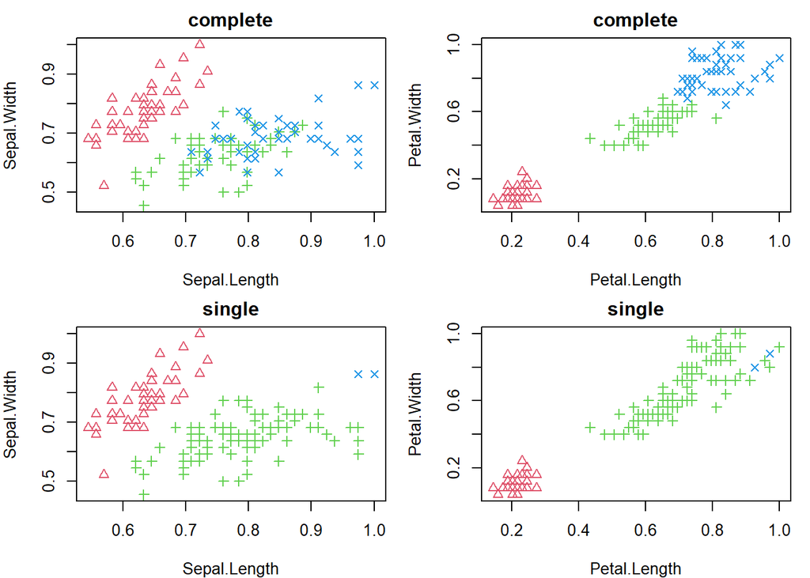

```r
res_complete <- cutree(Complete_hclust, 3)

res_single <- hclust(d = dist(Dat_Standardized), method = "single") %>% cutree(3)

res_average <- hclust(d = dist(Dat_Standardized), method = "average") %>% cutree(3)

res_centroid <- hclust(d = dist(Dat_Standardized), method = "centroid") %>% cutree(3)

par(mfrow=c(2,2))
par(mar=c(4,4,2,1))
## Results
plot(Dat_Standardized[,1:2], pch = res_complete + 1, col = res_complete + 1, main = "complete")
plot(Dat_Standardized[,3:4], pch = res_complete + 1, col = res_complete + 1, main = "complete")

plot(Dat_Standardized[,1:2], pch = res_single + 1, col = res_single + 1, main = "single")
plot(Dat_Standardized[,3:4], pch = res_single + 1, col = res_single + 1, main = "single")
```

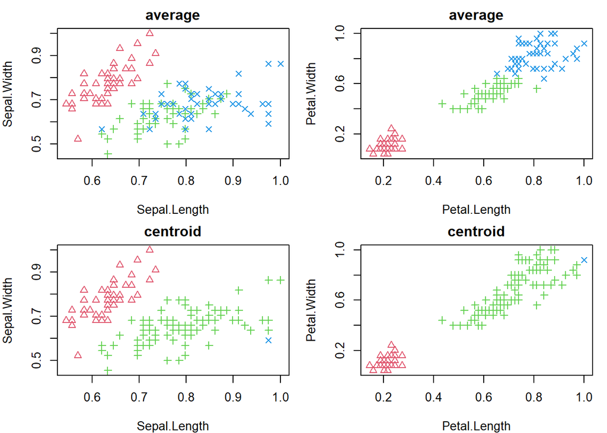

```r
plot(Dat_Standardized[,1:2], pch = res_average + 1, col = res_average + 1, main = "average")
plot(Dat_Standardized[,3:4], pch = res_average + 1, col = res_average + 1, main = "average")

plot(Dat_Standardized[,1:2], pch = res_centroid + 1, col = res_centroid + 1, main = "centroid")
plot(Dat_Standardized[,3:4], pch = res_centroid + 1, col = res_centroid + 1, main = "centroid")
```

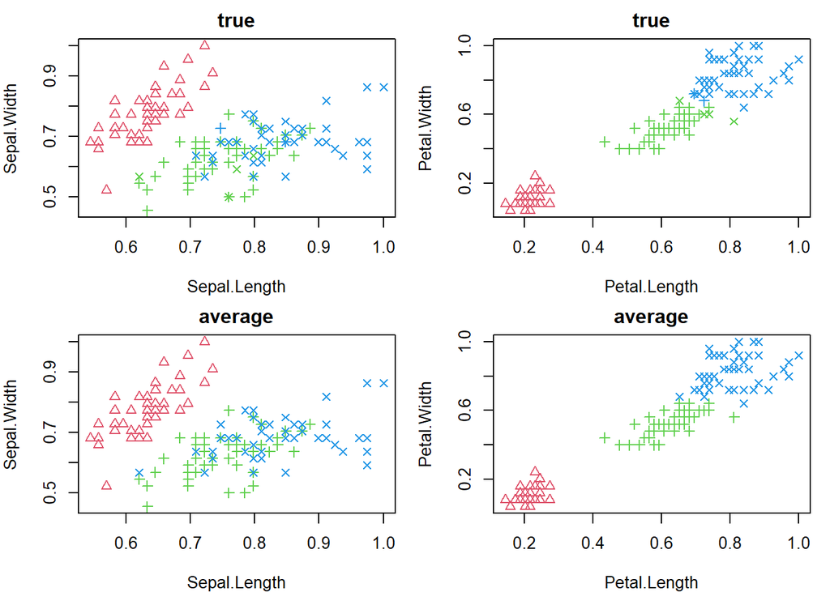

```r
##########True groupings ##########
plot(Dat_Standardized[,1:2], pch = Dat_Compare_Standardized$Species + 1, col = res_complete + 1, main = "true")
plot(Dat_Standardized[,3:4], pch = Dat_Compare_Standardized$Species + 1, col = res_complete + 1, main = "true")
plot(Dat_Standardized[,1:2], pch = res_average + 1, col = res_average + 1, main = "average")
plot(Dat_Standardized[,3:4], pch = res_average + 1, col = res_average + 1, main = "average")
```

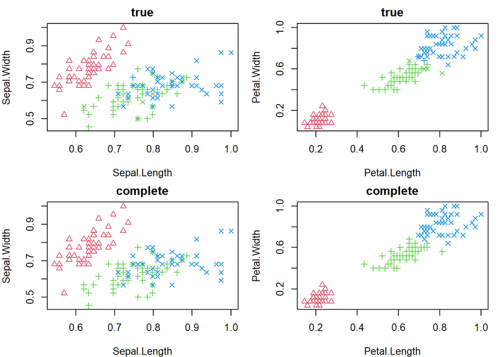

```r
#Very similar, unlike some of the other methods. Complete and average looks best for this problem.
plot(Dat_Standardized[,1:2], pch = Dat_Compare_Standardized$Species + 1, col = res_complete + 1, main = "true")
plot(Dat_Standardized[,3:4], pch = Dat_Compare_Standardized$Species + 1, col = res_complete + 1, main = "true")
plot(Dat_Standardized[,1:2], pch = res_complete + 1, col = res_complete + 1, main = "complete")
plot(Dat_Standardized[,3:4], pch = res_complete + 1, col = res_complete + 1, main = "complete")
```

Some of the chosen linkage methods actually gets very close to the right classification. However, when looking at the plots, it is also easy to see why it is hard to distinguish between 2 or 3 clusters.